# Bayesian Modelling 5A

Let Y = R2 and µ(y) = µ1(y1|y2)µ2(y2) where µ1(·|y2) is the density of the N1(y2, 1) distribution and µ2(·) is the density of the t5(0, 1) distribution (i.e. the Student distribution with 5 degrees of freedom, location parameter 0 and scale parameter 1). The goal of this problem is to implement in R a Metropolis-Hastings (M-H) algorithm that can be used to approximate µ. To this aim we consider a M-H algorithm where the proposal distribution Q(y, d~y) is the N2(y, c??) distribution, with c > 0 and ?? = ( 1 0.3 0.3 1 ), and where the starting value is y0 = (20, 20). Let T = 50 000 be the length of the trajectory we want to simulate.

1. Using the code below, implement the M-H algorithm described above in R and, looking at the acceptance rate and at the trace plots, propose a value for c. Justify your choices.

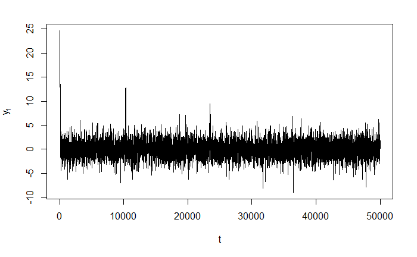

```r
# Load the package MASS that can be used to sample from
# multivariate normal distributions
library(MASS)
# Density of the distribution we want to sample from (in log)
density_target<-function(y){
return(dnorm(y[1],y[2],1,log=T)+dt(y[2],5,log=T))
}
# Function that samples from the proposal distribution
simulate_proposal<-function(y, Sigma){
return(mvrnorm(1,y,Sigma))
}
# Parameters to choose
T<-50000 #length of the trajectory
y0<-c(20,20) #starting value
c<-5
#THE CONSTANT TO CALIBRATE
Sigma<-c*matrix(c(1,0.3,0.3,1),2,byrow=T) #covariance matrix of Q
# To store the results
chain<-matrix(0,T,2)
acceptance_rate<-0
#Run the Metropolis-Hastings algorithm
chain[1,]<-y0
mu0<-density_target(chain[1,])
for(t in 2:T){
yt<-simulate_proposal(chain[t-1,],Sigma)
mu1<-density_target(yt)
if(log(runif(1))<=(mu1-mu0)){
chain[t,]<-yt
mu0<-mu1
acceptance_rate<-acceptance_rate+1
}else{
chain[t,]<-chain[t-1,]
}
}
acceptance_rate<-acceptance_rate/T
# Trace plots
plot(1:T, chain[,1], xlab='t', ylab=expression(y[1]), type='l')
```

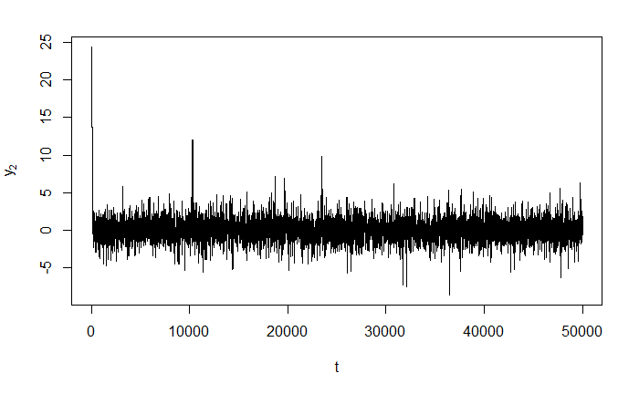

```r
plot(1:T, chain[,2], xlab='t', ylab=expression(y[2]), type='l')
```

2. It is a common practice to introduce a burn-in period, that is to discard the rst B iterations of the MCMC algorithm, where B is the time needed for the algorithm to be close to its stationary regime. Use the trace plots to propose a value for B.

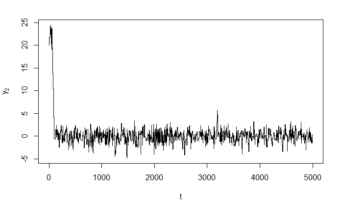

```r
plot(1:5000, chain[1:5000,2], xlab='t', ylab=expression(y[2]), type='l')
```

3. The auto-correlation functions (ACFs) can be computed using the package coda which provides functions for analysing the output from MCMC simulations. Using the following code, estimate the ACF for the two coordinates of the Markov chain and revise your choice for c if needed.

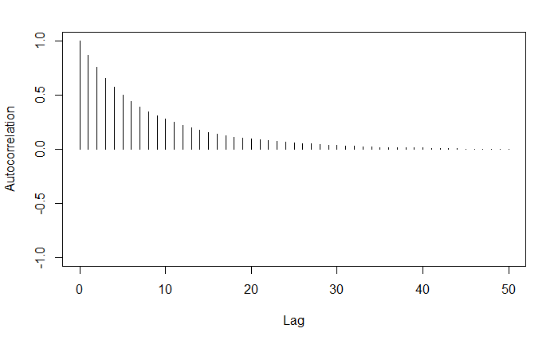

```r
# Load the package coda
library(coda)
# Length of the Burn-in period
B<-200
# Convert the simulated chain into an "mcmc object"
sample<-as.mcmc(chain[B:T,])
# Compute the ACFs for lags k=1,...,50
autocorr.plot(sample[,1],lag.max=50)
```

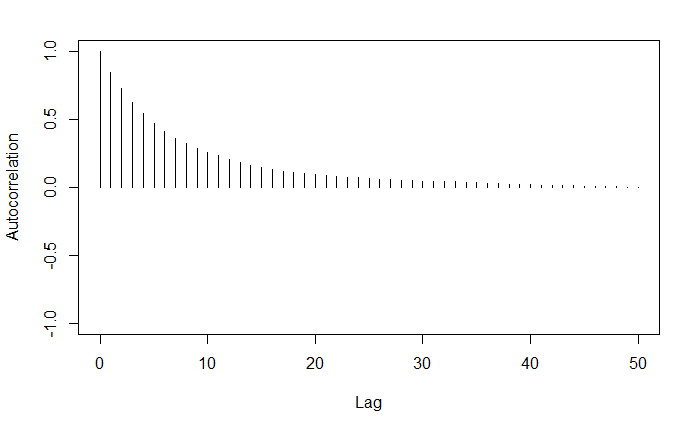

```r
autocorr.plot(sample[,2],lag.max=50)
```

Taking f : Y ??? R de ned by f(y) = y1, y ??? Y, the estimate µ^T ???B(f) can be computed as follows:

```r
# Function of interest
f<-function(y){
return(y[,1])
}
# Compute function evaluations
f_values<-f(sample)
# Estimated value of mu(f)
mean(f_values)
```

```
[1] -0.006686458
```

```r
spectrum0(f_values)$spec/length(f_values)
```

```
[1] 0.0008861307
```

```r
var(f_values)/length(f_values)
```

```
[1] 5.261125e-05
```

5. **For i ??? {1, 2} let fi**

   Y ??? R be de ned by fi(y) = yi , y ??? Y. Type the following command in R

```r
summary(sample)
```

[output not shown]

Problem 2 (JAGS)

To illustrate how JAGS can be run in from R let us consider the problem of approximating the posterior distribution

1. The rst step is to specify f(x, ??), the joint distribution of (X, ??). This step requires to write the model (expressed in BUGS notation) in a .bug le. This can be done using the following R code which writes µ in a le called Problem_2.bug

```r
# Load the package rjags
library(rjags)
# Write the model in the file `Problem_2.bug'
cat('
model{
x ~ dnorm(mu,tau)
mu ~ dnorm(mu_0, kappa_0*tau)
tau ~ dgamma(a_0,b_0)
kappa_0<-1/gamma_0
}
', file = 'Problem_2.bug')
```

2. The second step is to build the model using the command jags.model(), telling JAGS that we want to approximate f(x, ??) conditionally to x = 3 and supplying the parameters mu_0, gamma_0, a_0 and b_0 through the data argument, as in the following R code:

```r
mydata<- list(x=3, mu_0=0, gamma_0=1, a_0=2, b_0=2)
mymu <- jags.model('Problem_2.bug', data = mydata)
```

To verify that JAGS has recognized that the distribution of µ given (x, 1/??2 ) is a normal distribution while the distribution of 1/??2 given (x, µ) is a gamma distribution we can type:

```r
list.samplers(mymu)
```

```
$`bugs::ConjugateNormal`
[1] "mu"

$`bugs::ConjugateGamma`
[1] "tau"
```

3. The third step is to generate a trajectory of the Markov chain so-defined. Let us first run the Gibbs sampler for a burn-in period of B = 10 000 iterations:

```r
# Length of the Burn-in period
B<-10000
# Burn-in
update(mymu, n.iter=B)
```

[output not shown]

Then, we generate a trajectory of length T = 10 000

```r
T<-10000
sample <- coda.samples(mymu, c("mu", "tau"), n.iter = T)
```

[output not shown]

Remark: If we run the above code a second time then the new trajectory will start at t =n.iter+1. This way we can run the above code until the Markov chain enters in its stationary regime. If we are only interested e.g. in mu we can run the following code:

```r
sample <- coda.samples(mymu, c("mu"), n.iter = T)
```

[output not shown]

4. The last step is to assess the convergence of the Markov chain. The output of the coda_samples() command is an mcmc object (see Problem 1, part 3) and can therefore be directly analysed using the coda package. For instance:

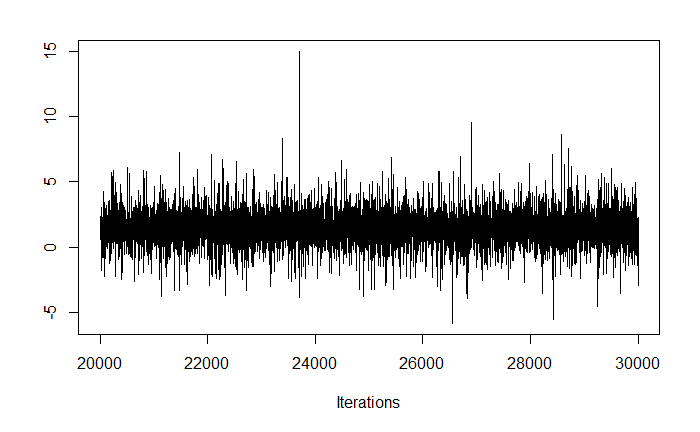

```r
# Trace plot for the first component (i.e. for mu)
traceplot(sample[,1])
```

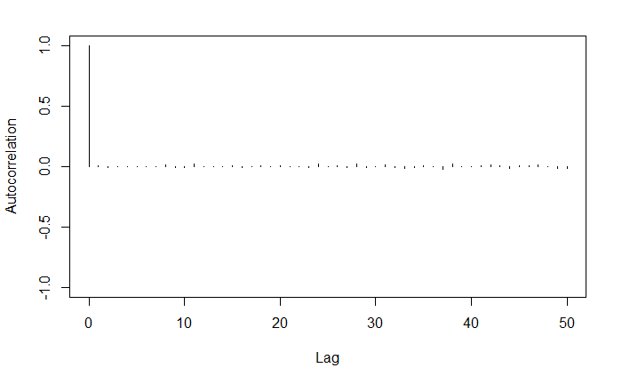

```r
# ACF for the first component (i.e. for mu)
autocorr.plot(sample[,1],lag.max=50)
```

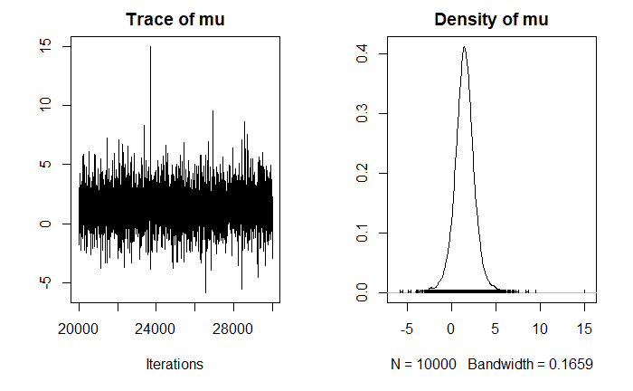

```r
# Trace plots for all the components (i.e. for mu and tau)
# and kernel density estimate of the marginal distributions
plot(sample)
```